# CaseStudyQTW6Q9and12_1 Positioning System

Celia Taylor, Chandan Nahar, Scott Anderwald

October 19, 2017

# MSDS 7333 Quantifying The World Unit 6 Project

# Predicting Location via Indoor Positioning Systems

#### The goal of of this project is to answer questions 9 and 12 from the Nolan and Lang textbook. These questions are quoted below.

##### “Q.9 The floor plan for the building (see Figure 1.1) shows 6 access points. However, the data contain 7 access points with roughly the expected number of signals (166 locations, 8 orientations, 110 replications = 146,080 measurements). With the signal strength seen in the heat maps of Figure 1.10), we matched the access points to the corresponding MAC address. However, two of the MAC addresses seem to be for the same access point. In Section 1.3.2 we decided to keep the measurements from the MAC address 00:0f:a3:39:e1:c0 and to eliminate the 00:0f:a3:39:dd:cd address. Conduct a more thorough data analysis into these two MAC addresses. Did we make the correct decision? Does swapping out the one we kept for the one we discarded improve the prediction?”

##### “Q.12 To predict location, we use the k nearest neighbors to a set of signal strengths. We average the known (x, y) values for these neighbors. However, a better predictor might be a weighted average, where the weights are inversely proportional to the distance (in signal strength) from the test observation. This allows us to include the k points that are close, but to differentiate between them by how close they actually are. The weights might be 1/di Pk i=1 1/di for the i-th closest neighboring observation where di is the distance from our new test point to this reference point (in signal strength space). Implement this alternative prediction method. Does this improve the predictions? Use calcError() to compare this approach to the simple average.”

##### Nolan, Deborah; Lang, Duncan Temple. Data Science in R: A Case Studies Approach to Computational Reasoning and Problem Solving (Chapman & Hall/CRC The R Series) (Page 41-42). CRC Press. Kindle Edition.

First order of business is to install all of the packages and libraries.

All of the packages and libraries were successfully loaded.

Next, we load the data.

```
## [1] 1181628      10
```

As shown above, the dimensions of the input file, offline.final.trace.txt are 1181628 rows by 10 columns. All of the data was successfully captured into a data frame.

```
## [1] 978443      9
```

```
##       time1       time2     scanMac        posX        posY        posZ
##    "POSIXt"   "POSIXct" "character"   "numeric"   "numeric"   "numeric"
## orientation         mac      signal     channel     rawTime
##   "numeric" "character"   "numeric" "character"   "numeric"
```

```
##       time                          posX         posY           posZ
##  Min.   :2006-02-11 01:31:58   Min.   : 0   Min.   : 0.0   Min.   :0
##  1st Qu.:2006-02-11 07:21:27   1st Qu.: 2   1st Qu.: 3.0   1st Qu.:0
##  Median :2006-02-11 13:57:58   Median :12   Median : 6.0   Median :0
##  Mean   :2006-02-16 08:57:37   Mean   :14   Mean   : 5.9   Mean   :0
##  3rd Qu.:2006-02-19 08:52:40   3rd Qu.:23   3rd Qu.: 8.0   3rd Qu.:0
##  Max.   :2006-03-09 14:41:10   Max.   :33   Max.   :13.0   Max.   :0
##   orientation      signal
##  Min.   :  0   Min.   :-99
##  1st Qu.: 90   1st Qu.:-69
##  Median :180   Median :-60
##  Mean   :167   Mean   :-62
##  3rd Qu.:270   3rd Qu.:-53
##  Max.   :360   Max.   :-25
```

```
##                 mac               channel                    scanMac
##  00:0f:a3:39:e1:c0:145862   2462000000:189774   00:02:2D:21:0F:33:978443
##  00:0f:a3:39:dd:cd:145619   2437000000:152124
##  00:14:bf:b1:97:8a:132962   2412000000:145619
##  00:14:bf:3b:c7:c6:126529   2432000000:126529
##  00:14:bf:b1:97:90:122315   2427000000:122315
##  00:14:bf:b1:97:8d:121325   2442000000:121325
##  (Other)          :183831   (Other)   :120757
```

```
## [1] 203
```

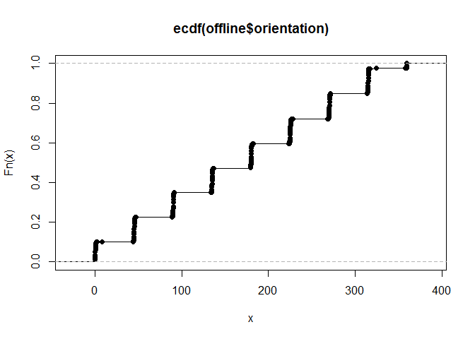

The plot above is a representation of “Figure 1.2:Empirical CDF of Orientation for the Hand-Held Device”, page 15 in the Nolan and Lang text previously referenced. This figure shows that the orientations of approximately 45 degree angles are not exact due to the data not being completely orthogonal and spread out.

```
## [1] 12  8
```

```
##
## 00:04:0e:5c:23:fc 00:0f:a3:39:dd:cd 00:0f:a3:39:e0:4b 00:0f:a3:39:e1:c0
##               418            145619             43508            145862
## 00:0f:a3:39:e2:10 00:14:bf:3b:c7:c6 00:14:bf:b1:97:81 00:14:bf:b1:97:8a
##             19162            126529            120339            132962
## 00:14:bf:b1:97:8d 00:14:bf:b1:97:90 00:30:bd:f8:7f:c5 00:e0:63:82:8b:a9
##            121325            122315               301               103
```

```
## 00:0f:a3:39:dd:cd 00:0f:a3:39:e1:c0 00:14:bf:3b:c7:c6 00:14:bf:b1:97:81
##                 1                 1                 1                 1
## 00:14:bf:b1:97:8a 00:14:bf:b1:97:8d 00:14:bf:b1:97:90
##                 1                 1                 1
```

```
## [1] 476
```

```
## [1] 310
```

```
## [1] 166
```

```
##   [1] 5505 5505 5506 5524 5543 5558 5503 5564 5513 5529 5526 5549 5526 5469
##  [15] 5464 5525 5429 5499 5532 5482 5396 5443 5358 5468 5447 5486 5483 5468
##  [29] 5444 5448 5503 5496 5472 5533 5459 5493 5543 5481 5539 5527 5490 5522
##  [43] 5433 5554 5463 5480 5409 5424 5526 5538 5442 5585 5556 5542 5526 5486
##  [57] 5560 5519 5507 5474 5447 5552 5500 5538 5365 5507 5409 5520 5551 5531
##  [71] 5615 5530 5517 5535 5474 5483 5541 5447 5506 5513 5519 5499 5576 5492
##  [85] 5473 5426 5529 5567 5528 5553 5595 5581 5519 5506 5437 5534 5536 5349
##  [99] 5331 5440 5448 5411 5470 5472 5671 5541 5514 5543 5452 5527 5543 5593
## [113] 5540 5531 5539 5621 5624 5495 5450 5500 5638 5586 5592 5619 5603 5626
## [127] 5477 5585 5588 5475 5559 5367 5461 5309 5330 5535 5395 5361 5494 5475
## [141] 5493 5481 5573 5527 5556 5504 5545 5553 5579 5692 5540 5492 5487 5589
## [155] 5463 5596 5557 5488 5523 5656 5524 5544 5734 5523 5553 5774
```

```
## [1] "matrix"
```

```
## [1]   3 166
```

```
##       [,1] [,2] [,3] [,4] [,5] [,6] [,7] [,8]
## posX  0    1    2    0    1    2    0    1
## posY  0    0    0    1    1    1    2    2
## count 5505 5505 5506 5524 5543 5558 5503 5564
```

```
##                  time posX posY orientation               mac signal
## 7 2006-02-11 01:31:58    0    0           0 00:0f:a3:39:dd:cd    -75
##   rawTime angle posXY medSignal avgSignal num sdSignal iqrSignal
## 7 1.1e+12     0   0-0       -67       -68 111      3.2       4.5
```

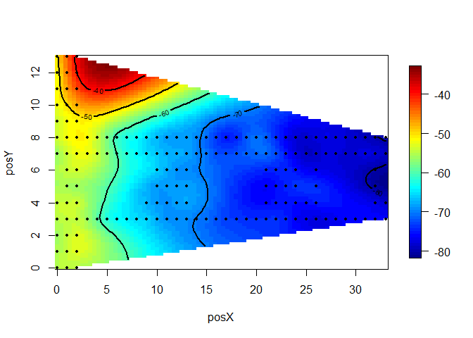

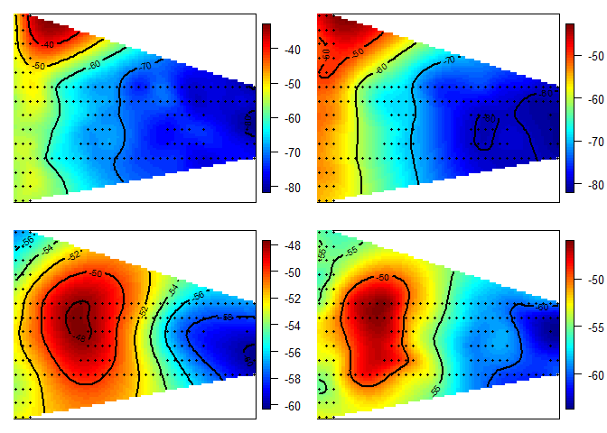

```
## $`00:14:bf:b1:97:90`
## NULL
##
## $`00:14:bf:b1:97:90`
## NULL
##
## $`00:0f:a3:39:e1:c0`
## NULL
##
## $`00:0f:a3:39:e1:c0`
## NULL
```

```
##                      x    y
## 00:0f:a3:39:dd:cd  7.5  6.3
## 00:14:bf:b1:97:8a  2.5 -0.8
## 00:14:bf:3b:c7:c6 12.8 -2.8
## 00:14:bf:b1:97:90  1.0 14.0
## 00:14:bf:b1:97:8d 33.5  9.3
## 00:14:bf:b1:97:81 33.5  2.8
```

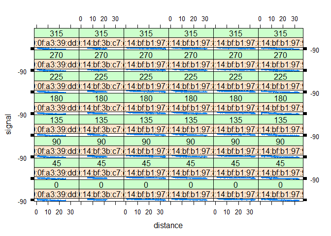

```
## [1] 412 270
```

```
## [1] 373
```

The above is the Cross Validation of from the …cd MAC address.

#### Question 12

To answer Question 12, we chose to compare results of the user defined function of findNN to the off-the shelf weighted KNN function, called kknn. The citation for the function or application is Hechenbichler K. and Schliep K.P. (2004) Weighted k-Nearest-Neighbor Techniques and Ordinal Classification, Discussion Paper 399, SFB 386, Ludwig-Maximilians University Munich.

#### Answer for Question 12

In order to answer this question, let’s first get the results of the baseline case, i.e. calcerror using the nearest neighbors using euclidean distance. This is calculated in the chunk below

#### Baseline Case for Question 12

```
## [1] 270
```

So our baseline sum of squares from findNN is 270 using the …cd MAC Address. We will now use the weighted average from kknn to calculate the sum of squares and re-run the calc error function to check if our sum of squares is lower than 270. In order to get the nearest neighbors based on weighted averages, we will make use of the kknn library, which finds the k nearest neighbors based on the Minkowski distance, which will give more credit to neighbors that are nearer vs. neighbors that are farther. This is in essence what we are trying to answer in questions 12. So let’s bring in the kknn library and tweak the predXY function to get the new sum of squares

## Estimation of calcerror using the kknn library

```
## [1] 253
```

#### Conclusion for Question 12

We find that our sum of squares improved only marginally using the kknn function (weighted distance) from 270 to 253. Therefore, in this case we do not get any material benefit for predicting the location of the signal.